# WaterPointDataExchange Descriptive Statistics

Vidya

12 July 2018

### This report is for analyizing Water Point Data . This data consists of 452549 records . These are the various water point data uploaded into Water Point Data Exchange across the world .

### The information of water point data consists of the location of water source , country name , the water source such as borewell , tap etc , technology with which water is made available , the source who reported the water point , quality of water , and the status of water point i.e whether water was available at the time of reporting.

### 1. Checking for zero values in the numeric fields . This is done so that if they are important fields , then need to check the reason for zero values.

```
                Row.ID         X.install_year              X.lat_deg
                     0                 121876                   2284
             X.lon_deg                  Count X.fecal_coliform_value
                  2280                      0                 446417
             Report.Yr
                     0
```

### It is shown that 2279 records have zero latitude and longitude values .

### Check the details of those records as follows:

```
 X.status_id.f             X.water_source.f          X.water_tech.f
 no     : 109   Borehole           :869                     :1598
 unknown: 500   Unknown            :328     Bush Pump Type B: 273
 yes    :1670   Protected Spring   :306     Bucket Only     : 201
                Protected Borehole :233     Other           :  47
                Unprotected River  : 91     Rope and Bucket :  46
                Protected Deep Well: 64     Bush Pump Type A:  29
                (Other)            :388     (Other)         :  85
                                                                         X.source.f
 Evidence Action                                                              :1598
 The Zimbabwe Rural Water, Sanitation &  Hygiene Management Information System: 675
 Water For People                                                             :   3
 Ministry of Water Resources Sierra Leone                                     :   1
 Swaziland Department of Water Affairs                                        :   1
 TEST                                                                         :   1
 (Other)                                                                      :   0
 X.country_id.f   X.lat_deg   X.lon_deg   Report.Dt
 UG     :1599   Min.   :0   Min.   :0   Min.   :2012-09-20
 ZW     : 675   1st Qu.:0   1st Qu.:0   1st Qu.:2013-01-25
 BO     :   1   Median :0   Median :0   Median :2013-10-05
 MW     :   1   Mean   :0   Mean   :0   Mean   :2014-03-29
 PE     :   1   3rd Qu.:0   3rd Qu.:0   3rd Qu.:2015-04-10
 SL     :   1   Max.   :0   Max.   :0   Max.   :2017-06-29
 (Other):   1
```

### 2. Water_tech and water_source values need to be cleant . There is no standard value for each type of water source and water technology . This hampers in modelling for prediction of water status and is not informative.

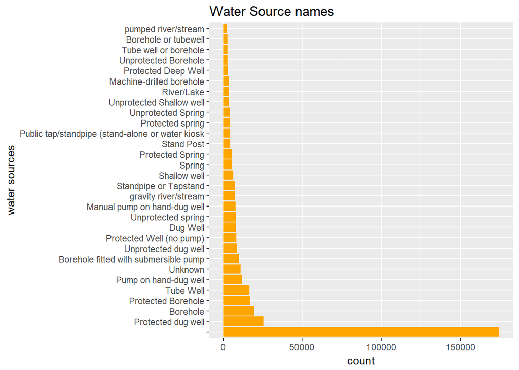

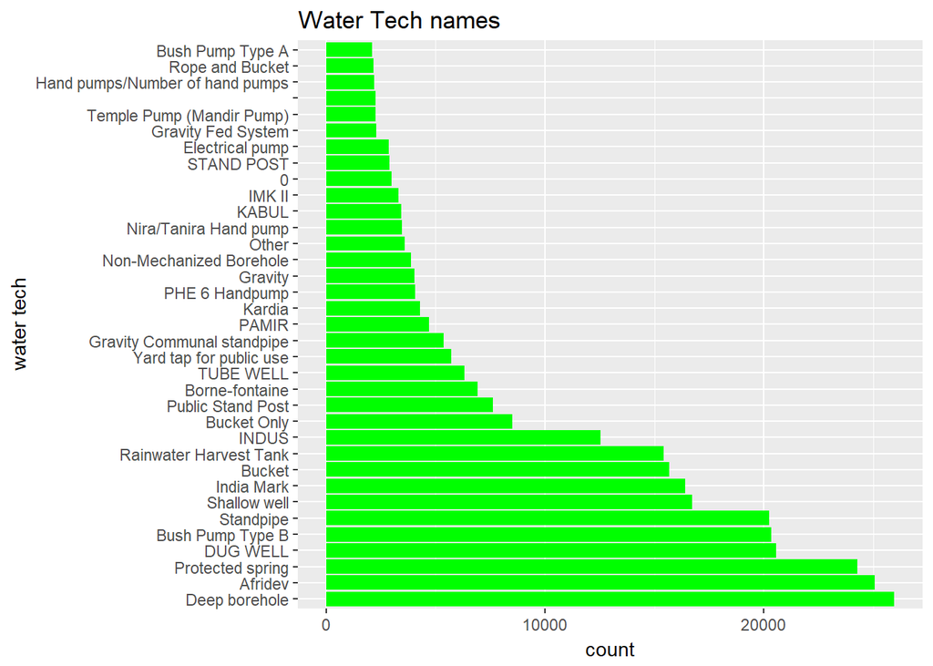

### 3. How many waterpoints are uploaded by year and how many are of them are functional ? The following graph provides the required information.

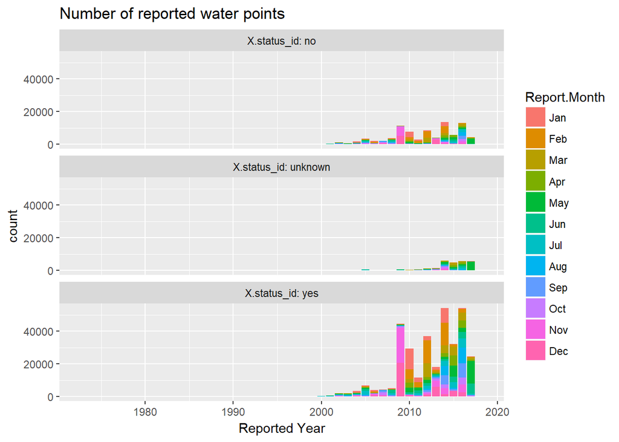

```
   Min. 1st Qu.  Median    Mean 3rd Qu.    Max.
    1.0     3.0    32.0   511.4   238.0 21375.0
```

### Hence displaying the water point records for years that have uploads more than 238 .

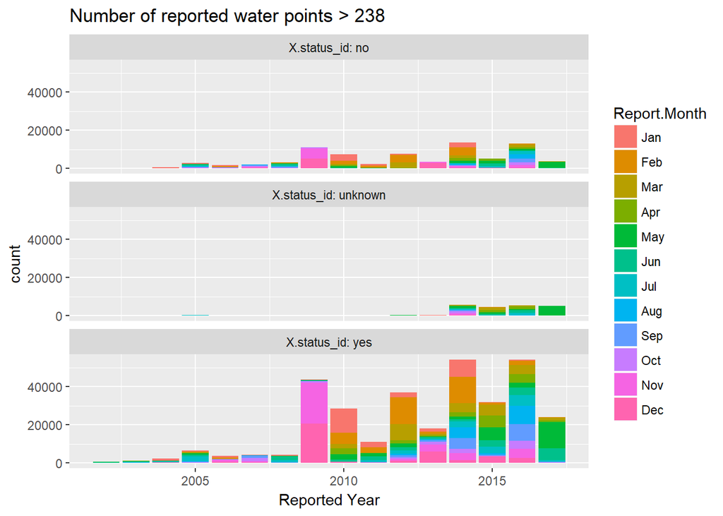

### 4. Distribution of waterpoints by country .

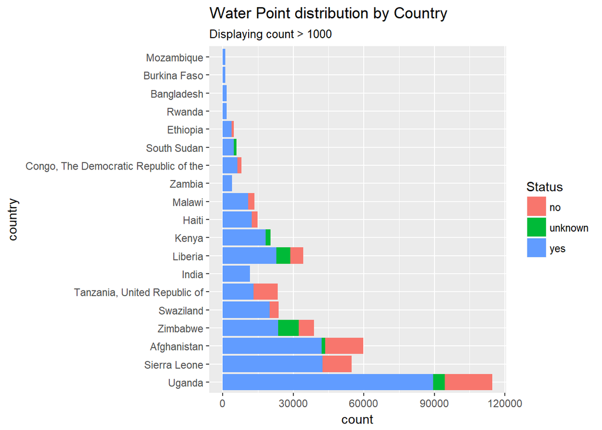

### 5. Visualizing the distribution on map . This is to display first 1000 water points.

### Water points can be clustered further and displayed on the map.

### It helps in understanding the proximity of the water points .

[interactive chart not shown]

### 6. Water points distribution by Country and the Reporting Year

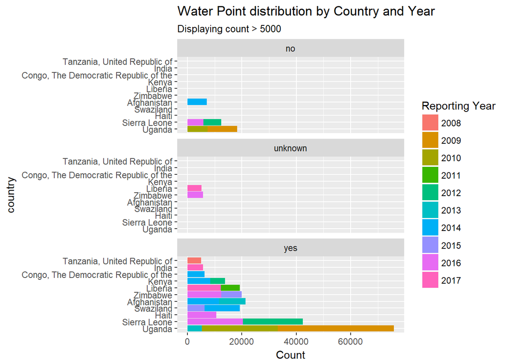

### 7. Source of the uploaded water point is a mandatory field. It provides the name of the organization collecting and reporting the data record.

### Distribution of water points by the sources and to check many are functional ?

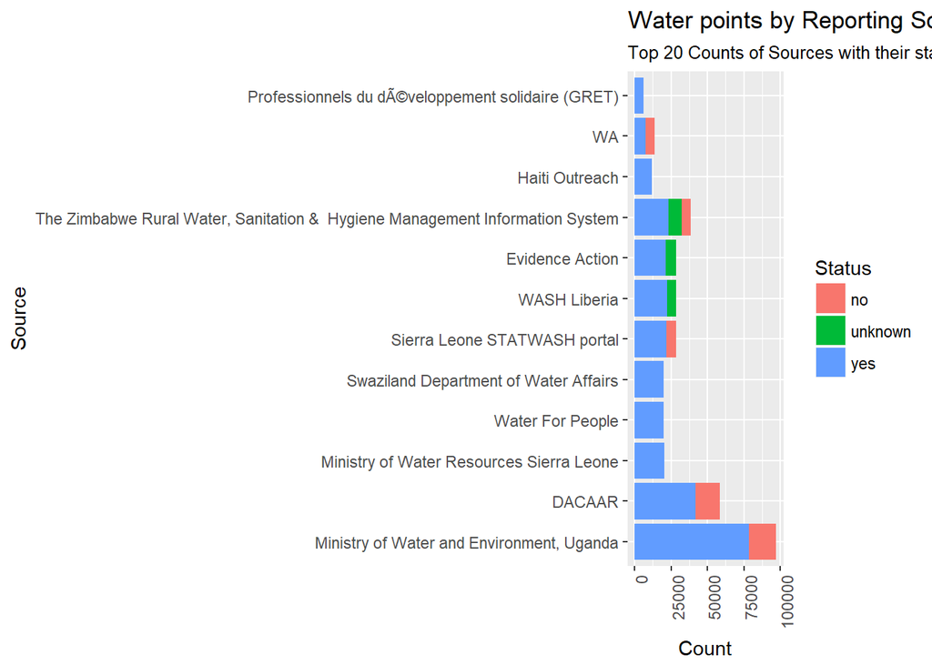

### 8. What are the various status descriptions which tells the condition of a waterpoint? Can we understand the most common problems related to non functionality of water point ?

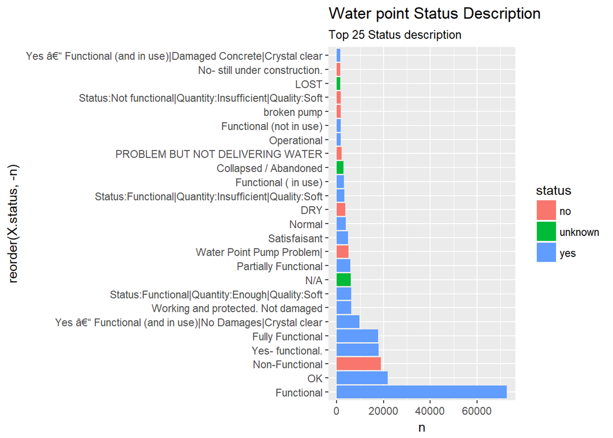

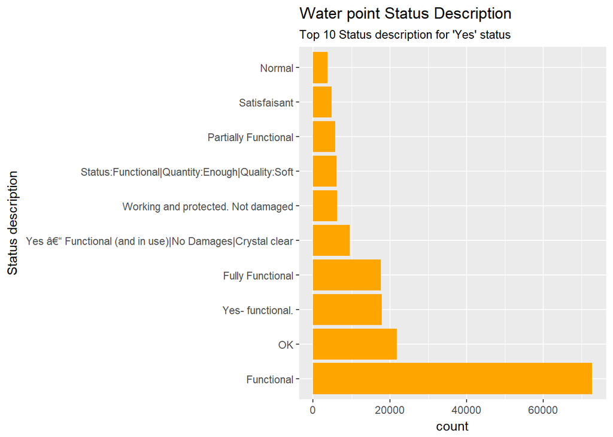

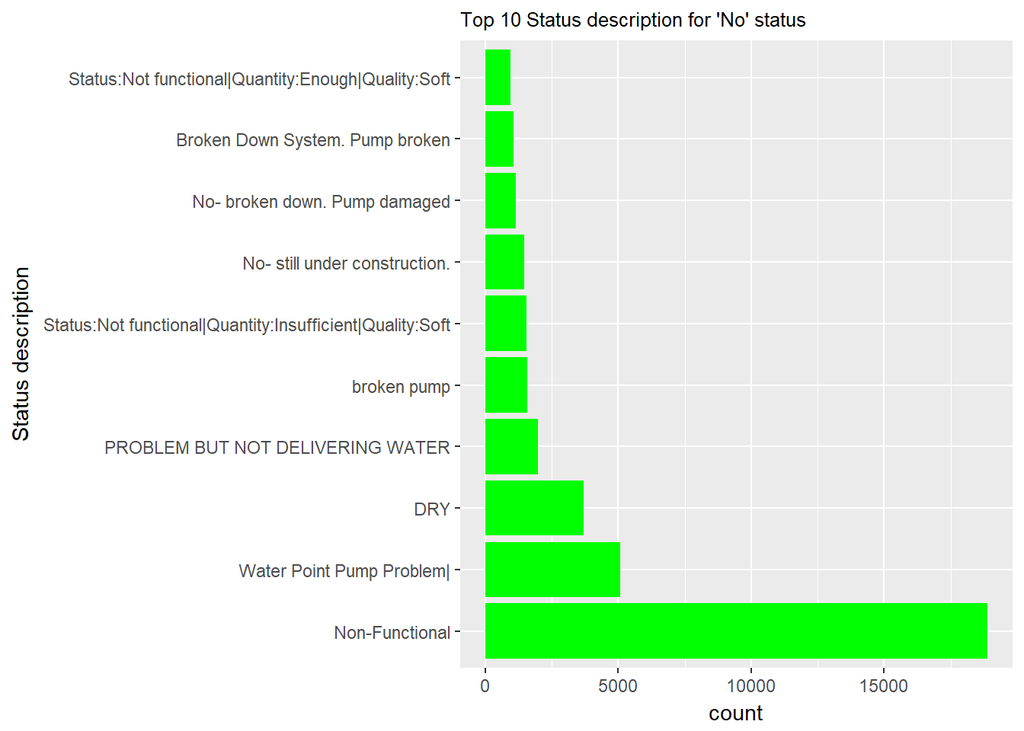

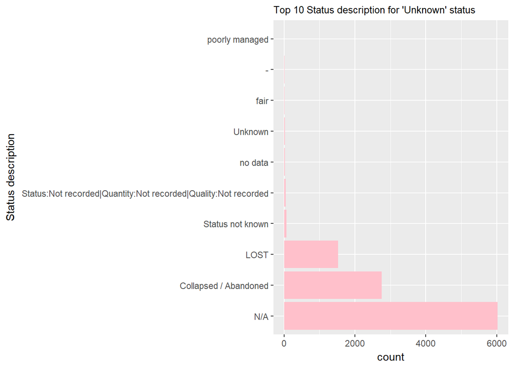